# Class 24

## Final???

Pared down from normal

probably ~2 hours. Midterm+

Basically like a homework

R section will be open book

First part will be text identification, from Shakespear, Austen, Blake ~10 of them

Then it will be normal where’s waldo, commenting, similar to the mid-term

“I used to go to shonney’s and lick the sneeze guard for fun” - Regarding the before time.

## Clustering

Unsupervised Activity

Putting Texts in a pile, can do different things

Might sort shakespear texts into 4 piles, computer puts similar things into same pile.

Today we will look at how this is done.

Mike Whittmore did some, Othello kept showing up with the comeides

Today we will cluster emma and fan fiction, and some blake.

Can do it where you specify the piles, or let the computer find the number of piles.

## Dendograms - Trees

An alternative way to cluster is K-means clustering

## Today’s Functions

dist() hclust() seq_along() prop.table() mapply()

## The republic of pemberley

Jane Austen fan group * Collection of fan fiction

Wierd family trees

Lots of characters parented by people who are not their parents

## Back to Yes, yes, No, no

Back to looking at these text from a few classes before.

## To the code!

Shifting from theta to thinking about distance between two points

Pythagorean Theorem

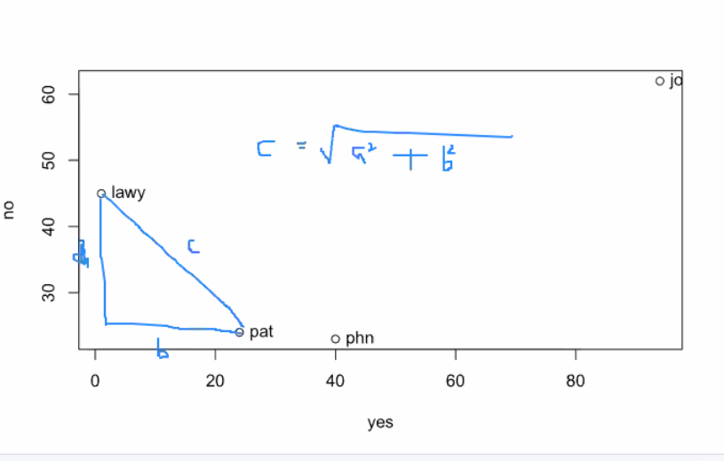

Distance is scalar, dimensions don’t really matter

What is the difference between saying they are similar because they are computationaly near or saying they are near because I read all of the novels and think that.

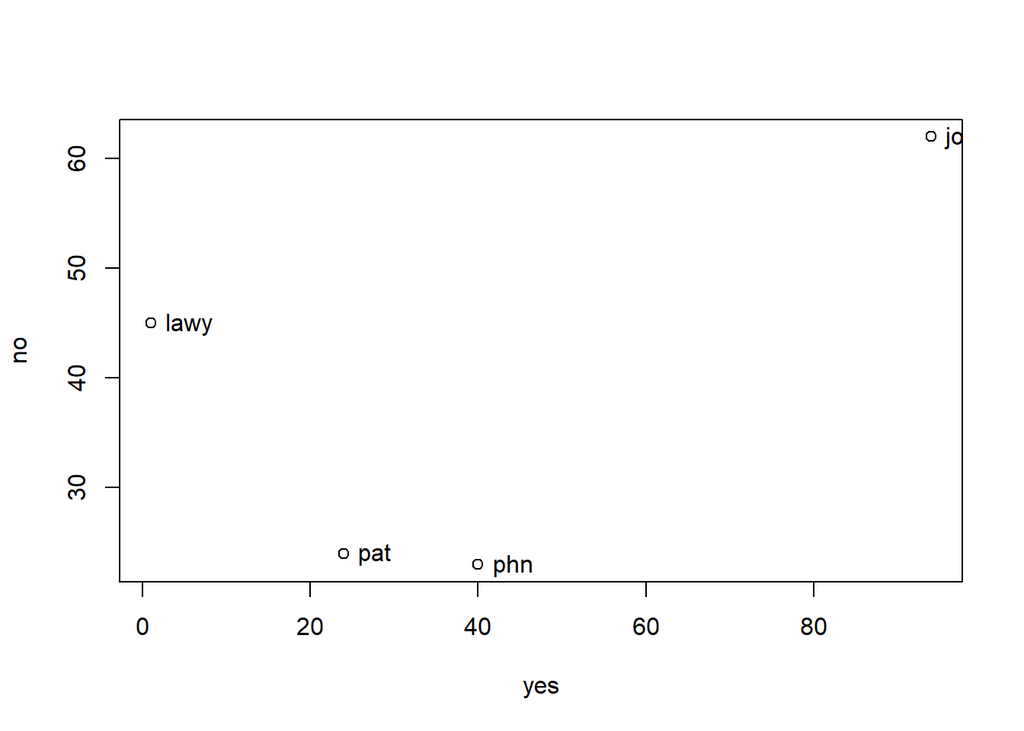

```r
# Hacking, Class 24
# Clustering

# We'll focus on "hierarchical clustering"
# More to read about clustering here: https://www.stat.berkeley.edu/~s133/Cluster2a.html

# 3 texts
# (Yeses, Nos)
pat<-c(24,24)
joy<-c(94,62)
phn<-c(40,23)
lawy<-c(1,45) # adding a text... Imagining the way your lawyer wants you to answer questions...

# a matrix of texts and counts
yes.m<-rbind(pat,joy,phn,lawy)
colnames(yes.m)<-c("yes","no")
plot(yes.m)
text(yes.m,labels=row.names(yes.m),pos=4) # add labels to the points
```

```r
# calculate distances and cluster
# These distances are all relative
dm<-dist(yes.m) # compressed
dm<-dist(yes.m,diag=T) # 3 x 3

# Class distance
class(dm)
```

```
## [1] "dist"
```

```r
str(dm)
```

```
##  'dist' num [1:6] 79.6 16 31.1 66.6 94.5 ...
##  - attr(*, "Size")= int 4
##  - attr(*, "Labels")= chr [1:4] "pat" "joy" "phn" "lawy"
##  - attr(*, "Diag")= logi TRUE
##  - attr(*, "Upper")= logi FALSE
##  - attr(*, "method")= chr "euclidean"
##  - attr(*, "call")= language dist(x = yes.m, diag = T)
```